Skip to book

# How to read this book

**Hung-Fu Chang, Ph.D. and Wenhui Zhu, Ph.D.**

This book teaches JavaScript in the order a young game designer needs it. Instead of memorizing programming rules first, you will meet a problem inside a game and learn the programming idea that solves it.

Each part is a milestone of your understanding of using JavaScript to build a game.

Chapter 1 prepares your computer and project files. Chapter 2: Design and develop a game starts with a game story and plans feature-by-feature iterations of Structure → Style → Behavior. Then build one small scene in three gradual lessons: Chapter 3: Structure, Chapter 4: Style, and Chapter 5: Behavior. Try each chapter’s examples and exercises before continuing to JavaScript in Chapter 6. The HTML/CSS reference keeps the detailed catalog available for later lookup.

## Study guide: Read → Code → Exercise

Use this three-step process for each new topic. Work through one concept at a time before moving to the next.

1. **Read:** Read the explanation and study the diagrams. Identify the problem the idea solves, then explain the idea in your own words. Before running the example, predict what it will do.
2. **Code:** Type the example into the appropriate project file and run it. Compare the result with your prediction. Trace how the code uses the concept, then change one small thing and observe what happens.
3. **Exercise:** Try the related exercise or challenge on your own. Use the concept to plan your solution, write the code, and test the result. Explain why your solution works. If you get stuck, reread the concept and revisit the example, then try again.

Repeat **Read → Code → Exercise** throughout the chapter. For game-building tasks, use **Structure → Style → Behavior** to help your thinking and then organize your work during the coding and exercising steps.

## Choose your reading path

Chapters 1-15 establish the web and JavaScript foundations. Chapters 16-19 build a complete 2D adventure. Chapters 20-23 introduce Three.js, custom 3D models, and Rapier physics. The later projects take more time and combine earlier ideas; work through them in small experiments.

Purple **Advanced Study** blocks are optional deeper dives into HTML, CSS, JavaScript, and game systems. They start open; you can collapse them while following the main path and return later.

**Understand**

Blue blocks introduce the big idea.

**Build**

Green blocks hold your mission and challenges.

**Go deeper**

Purple blocks explain what happens underneath.

**Explain**

Rose blocks help you check your understanding.

## Read examples carefully

A **complete example** includes the setup for that small project. A **code fragment** illustrates one part of a game and relies on the variables or functions discussed nearby. Do not paste every fragment into one file without checking where it belongs: some examples replace earlier versions.

Chapters 12–14 use Pong, Breakout, and Snake to explain larger game-building patterns. Each chapter includes a complete small browser example alongside fragments explaining individual rules. Locate its scene, its style, and its actions before changing a fragment. Chapters 16-23 add complete companion projects in the Game Lab. Their chapter snippets explain selected parts; the linked project folders contain the complete runnable source.

## A safe learning habit

When a program does not work, do not immediately replace it with someone else’s code. Read the browser console, compare one small section at a time, and explain what you expected to happen. Debugging is part of programming, not evidence that you failed.

## Your game-making journey

| Chapter | Game | Coding ideas | Your new ability |
| --- | --- | --- | --- |
| 1 | Computer and web basics | Client, browser, files, servers | Explain where a web page comes from |
| 2 | Design and develop a game | Game story, small features, iterative Structure → Style → Behavior | Plan and test features, then connect the plan to HTML, CSS, and JavaScript |
| 3 | Structure: Monster Clicker page | Small idea, sketch, HTML elements, attributes, nesting | Build and check the parts of a scene |
| 4 | Style: Monster Clicker appearance | CSS rules, selectors, text, boxes, focus | Make the existing scene readable |
| 5 | Behavior: Monster Clicker action plan | Input controls, state, rules, feedback, tests | Predict actions and plan game behavior |
| 6 | Monster Clicker Starter | Variables, arrays, objects | Prepare memory for game actions |
| 7 | Make the Page React | DOM, events, functions | Connect player actions to page updates |
| 8 | Monster Decisions | Conditions, branches | Enforce game rules |
| 9 | Monster Swarm | Arrays, loops | Process a collection of monsters |
| 10 | Catch the Star | Timers, coordinates, DOM | Change the page over time |
| 11 | Bouncing Ball | Canvas, animation | Draw every frame yourself |
| 12 | Pong | Keyboard, game loop | Read keys while the game keeps running |
| 13 | Breakout | Arrays, collision | Manage many objects |
| 14 | Snake | Grid logic, state | Update a world one step at a time |
| 15 | Game Studio | Planning, polish, final project | Design your own rules |
| 16 | Collision Playground | Input, velocity, fixed steps | Build a predictable real-time loop |
| 17 | Platforms and jumping | Hitboxes, collision response, gravity | Stop at walls and land on platforms |
| 18 | Your own 2D artwork | Sprite sheets, loading, JSON levels | Make the game look like your design |
| 19 | Robot Orchard | Scrolling, enemies, goals, restart | Finish a complete 2D adventure |
| 20 | Robot Island Explorer | Scene, camera, renderer, 3D movement | Build and explore a 3D world |
| 21 | 3D Asset Workshop | GLB models, origins, materials | Customize and import 3D artwork |
| 22 | Rapier Drop Lab | Bodies, colliders, bounce, fixed steps | Connect physics to the picture |
| 23 | Marble Quest | Forces, sensors, scoring, respawn | Finish a 3D physics game |

## Open the Game Lab

The companion Game Lab contains six complete projects, including two experimental labs, two collectible adventures, a 3D exploration game, and a model-customization workshop. Keep the project folders together so their shared code and assets can be found.

Run the later projects

From the extracted textbook folder, run `node scripts/serve.mjs`. Open `http://127.0.0.1:8000/games/` in your browser. This local server needs Node.js but no package installation. Use the Game Lab guide for controls, file locations, and troubleshooting.

The 2D projects use local files only. The 3D projects initially download pinned Three.js and Rapier modules from a CDN, so they need an internet connection and a browser with WebGL2. An optional dependency-download script supports later offline use.

# 1 Computer, Browser, and Web

WEB 01 | Before we build a web game

Hardware Software Browser Web URL Server

## Overview

Before you build a web game, it helps to know **where the game lives**, **what runs it**, and **how the pieces reach the screen**.

A web game may look like one thing when you play it, but several parts work together behind the scenes. Your computer provides the hardware. Programs such as a browser provide the software. Files store the pictures, sounds, page information, and game instructions. The Web lets a browser request files from other computers when those files are not already on your own computer.

You do **not** need to memorize every technical word in this chapter. The goal is to build a simple picture in your mind. Later chapters will add HTML, CSS, and JavaScript to that picture one step at a time.

The big picture

When you play a web game, you are usually using **software** called a browser on **hardware** such as a laptop or desktop computer. The browser opens game files from your computer or receives them from a server, then uses those files to show and run the game.

`{mermaid} flowchart LR A[Computer hardware] --> B[Browser software] C[Game files] --> B B --> D[Web game on the screen]`

**Read the picture:** The computer is the physical machine. The browser is a program running on that machine. The browser uses files to create the game experience you see.

## Learning Objectives

By the end of this chapter, you will be able to:

- explain the difference between a **program**, a **file**, and a **folder**;
- create, name, copy, and organize project files, then save and reopen them;
- explain what a **browser** does;
- distinguish the **Internet** from the **Web**;
- distinguish a **web page**, **website**, and **web game**;
- explain what a **URL** is and recognize its basic parts;
- describe the jobs of a **client** and a **server**;
- trace a simple **request and response** between a browser and a server;
- explain the difference between opening a **local file** and visiting a web address;
- describe, at a high level, where a web game can do its work.

### What is a program?

A **program** is a set of instructions that a computer can follow. A browser is a program. A calculator app is a program. A game is also a program.

When you start a program, the computer loads the instructions and begins carrying them out. Some programs open documents. Some programs play music. A browser opens and runs web content.

For this book, two programs will be especially important:

- A **text editor** lets you create and change code files.
- A **web browser** reads web files and shows the result.

You will spend a lot of time moving between these two programs: edit something, save it, return to the browser, and see what changed.

## 1.1 Files and folders keep a project organized

Computers store information in **files**. A file can contain many kinds of information: words, pictures, music, video, data, or program instructions.

A **file name** helps you recognize a file. Many file names also end with a **file extension**, such as `.png` or `.txt`. The extension gives people and programs a clue about what kind of information the file contains.

A **folder** is a container used to organize files and other folders.

Think of a folder as a project box. If you make a space game, you want the files for that game to stay together instead of being scattered around your computer.

```
space-game/
  index.html
  styles.css
  game.js
  images/
    spaceship.png
    planet.png
  sounds/
    launch.mp3
```

These are real web-project file names. `index.html` describes the page, `styles.css` describes its appearance, and `game.js` holds JavaScript instructions. The name `index.html` is a common starting-page name. An early example may keep all three kinds of code inside one HTML file; a larger project usually separates them.

| File category | Extensions used in this book | Browser’s job |
| --- | --- | --- |
| Page | `.html` | Read the page structure and find its linked resources. |
| Stylesheet | `.css` | Apply colors, sizes, spacing, and layout rules. |
| Program | `.js` | Run the game instructions. |
| Picture | `.svg`, `.png` | Display an image or use it in a game drawing. |
| Sound | `.wav`, `.mp3` | Load audio that the game can play. |
| Data | `.json` | Read organized information, such as a level layout. |
| 3D model | `.glb` | Supply model data to the later 3D game code. |

Try It: Find a file and its folder

Open a folder on your computer. Pick one file and answer these questions:

1. What is the file’s name?
2. Does it have a file extension?
3. Which folder contains it?
4. Which program would you use to open it?

## 1.2 The Internet and the Web are related, but they are not the same thing

People often use the words **Internet** and **Web** as if they mean the same thing. They are related, but they describe different ideas.

The **Internet** is a huge network that connects computers and devices around the world. It is the communication system that lets connected computers exchange information.

The **World Wide Web**, usually called the **Web**, is a system of pages and other resources that we access through the Internet, usually with a web browser.

One simple way to remember the difference is:

- **Internet:** the network that connects computers.
- **Web:** pages, sites, games, pictures, and other resources that browsers access using that network.

`{mermaid} flowchart LR A[Your computer] --> B[Internet<br/>connects computers] B --> C[Web server] C --> D[Web pages and game files]`

The Internet can be used for things other than the Web. The Web is one important service that uses the Internet.

A useful comparison

Imagine roads connecting many towns. The **Internet** is like the road system. A **website** is like a place you can reach using those roads. A **browser** is one of the tools that helps you travel to and use that place.

The comparison is not perfect, but it can help you keep the words separate.

## 1.3 A browser is software that works with web resources

A **web browser** is software that helps you open and use web pages and web applications. Chrome, Edge, Firefox, and Safari are examples.

A browser can get web files in two common ways:

1. It can open files that are already stored on your computer.
2. It can request files from another computer through a network.

After it receives the files, the browser uses them to create what you see and interact with on the screen.

`{mermaid} flowchart LR L[Files on your computer] -->|open| B[Browser] B --> S[What you see and use] W[Files from a web server] -->|receive| B`

[figure not shown]

An annotated browser view showing its address bar above the displayed web page.

**Read the picture:** The address bar belongs to the browser. The heading, words, and button below it belong to the web page the browser displays.

### What happens when you type something in the address bar?

The long box near the top of a browser is usually called the **address bar**. You can use it to enter a web address. Browsers can also send words from the address bar to a search engine, so typing into the address bar does not always mean that you typed a web address.

When you enter a web address, the browser tries to find the resource at that address. If the resource is on another computer, the browser sends a request for it.

## 1.4 A URL tells a browser where to look

A **URL** is an address for a resource. URL stands for **Uniform Resource Locator**.

You can think of a URL as directions that help a browser locate something. That “something” might be a web page, an image, a game file, or another resource.

Here is a simple example:

```
https://example.com/games/space-quest
```

For now, focus on three parts:

| Part | Example | What it tells us |
| --- | --- | --- |
| Scheme | `https://` | how the browser should communicate |
| Domain | `example.com` | which site or server name to contact |
| Path | `/games/space-quest` | which resource or location to ask for |

You do not need to memorize every possible URL part yet. The important idea is that a URL gives the browser an address it can use.

Advanced Study: A URL can contain more parts

A URL can include additional information. For example:

```
https://games.example.com:443/levels/maze?mode=easy#start
```

It may contain:

- a **scheme** such as `https`;
- a **host name** such as `games.example.com`;
- an optional **port** such as `443`;
- a **path** such as `/levels/maze`;
- an optional **query** such as `?mode=easy`;
- an optional **fragment** such as `#start`.

You will not need most of these pieces to begin making games. Return to them when a later project needs them.

## 1.5 Local files and web addresses

## Your computer toolkit

Before you make a game, meet the tools you will use. A **computer** runs programs: sets of instructions that tell it what to do. A web browser is one program. A text editor is another. You are about to write instructions that a browser can follow.

When do I need to install a local web server?

**Chapters 3–15:** the supplied one-file games open directly in a browser. **Chapters 16–23:** all six Game Lab projects require a local HTTP server. Install **Node.js LTS** once from nodejs.org/en/download, then use the included Windows or Mac launcher each time you play. The Game Lab guide has the game-by-game requirements and step-by-step installation. The four 3D projects also need internet for library downloads by default.

### Files and folders

A **file** is one named piece of information saved on a computer. A game picture, a sound, and a page of code can each be files. A **folder** is a container that helps you keep related files together. Think of a folder as a game box and the files inside as its cards, pieces, and rule sheet.

Give each game its own folder. For example, your `my-first-game` folder can hold its HTML page now and later hold pictures, sounds, and more JavaScript files. Keep those files together when you copy or move your game.

### A text editor is for code

You write code in a **plain-text editor**. It saves exactly the letters, numbers, spaces, and punctuation that you type. Many editors color code and point out mistakes; that can be helpful, but the colors are not part of the code.

A word processor is great for essays, but it may add special quotation marks, hidden formatting, or page layouts. Those extras can confuse code. Use a plain-text editor for your game files. Ask your teacher which editor is available on your computer.

### File names and extensions

The end of a file name after the final dot is its **file extension**. It helps people and programs recognize the file’s job.

| File name | What it usually contains |
| --- | --- |
| `index.html` | The page structure a browser opens. |
| `main.js` | JavaScript instructions for the browser. |
| `style.css` | Colors, sizes, and other visual choices. |
| `level.json` | Organized game data, such as a level layout. |
| `robot.svg` | A picture made from shapes and lines. |

The extension is important. `index.html` and `index.html.txt` are different files: the first is a web page, while the second is usually treated as ordinary text. Some computers hide extensions, so check the full name when you save a file. Do not rename a file just to give it a new extension; save it in the right kind of file from the start.

A browser does not always need to get a page from the Internet. It can also open a file stored directly on your computer.

A local file address may begin with `file:///`. For example:

```
file:///Users/your-name/Documents/space-game/start.html
```

The important part is not the exact folder name. `file:///` tells you that the browser is opening a file from the local computer.

A web address often begins with `http://` or `https://`:

```
https://example.com/games/space-quest
```

That normally tells the browser to contact a server through a network.

| Address begins with | Usual meaning |
| --- | --- |
| `file:///` | open a file stored on this computer |
| `http://` | request a web resource using HTTP |
| `https://` | request a web resource using encrypted HTTP communication |

## Tool

- A modern web browser Chrome.
- A text editor in your computer. You can use Notepad in Windows or TextEdit in MacOS. We suggest to use Sublime Text (text editor) or VSCode (development tool).

## Preparation

Start with one file

Open it in your browser. After editing, save the file and refresh the browser. Later, module-based projects need a local development server.

## Meet the browser team

Your web browser is the program that turns your game files into a page you can play. Three kinds of code often work together:

| Part | Its job | A game example |
| --- | --- | --- |
| **HTML** | Builds the page and names its parts. | A heading, a button, and a canvas. |
| **CSS** | Chooses how those parts look. | A purple button or a large play area. |
| **JavaScript** | Makes the page react and change. | Add a point when the player clicks. |

Use **Build the scene structure → Style the scene → Program game behavior**: HTML describes the first pages, CSS makes their parts readable, and JavaScript adds game operations and actions. Chapter 4 uses linked HTML and CSS files; Chapter 6 combines a styled scene and JavaScript data in one starter file.

### What “client-side JavaScript” means

The **client** is the player’s browser. Client-side JavaScript runs on the same computer, tablet, or Chromebook that displays the game. When a player presses a key, the browser can run your JavaScript right there and update the picture right away.

That is different from code on a **server**—another computer that can store shared scores, accounts, or messages. Our first games do not need a server on the internet. Their rules and scores stay in the browser while the page is open.

## Run a one-file game from your drive

For the complete examples in the first chapters, you can run your game directly from your computer’s drive.

1. Make a folder called `my-first-game` somewhere you can find again, such as Documents.
2. In a plain-text code editor, save the complete example as `index.html` inside that folder. Check that the name ends in `.html`, not `.html.txt`.
3. Open the folder and double-click `index.html`. Your browser should open it. You may see an address beginning with `file:///`; that means the browser opened a file from your own drive.
4. Return to the editor, make one small change, save, and refresh the browser page. On many computers, refresh is `Ctrl+R` or `Command+R`.

If double-clicking opens an editor instead of a browser, right-click the file and choose **Open with**, then choose your browser. If you cannot see the `.html` ending, ask an adult or teacher to turn on file-name extensions. A file named `index.html.txt` is a text document, not a web page.

## When a local web server helps

Some later games use several JavaScript files, images, level-data files, or 3D models. A **web server** is a small program that hands files to a browser when the browser asks for them. It is like a careful librarian: the browser asks for a particular file, and the server gives back that file.

For a one-file beginner game, `file:///` is enough. For a project that uses JavaScript `import`, JSON data, or files loaded by the game, start a **local web server** instead. A local server runs only on your own computer and gives the page an address such as `http://127.0.0.1:8000/`. Modern browsers use extra safety rules for those multi-file requests, so opening the HTML by double-clicking may not work.

`127.0.0.1` means “this same computer.” Starting this book’s local server does not put your game on the internet or let classmates visit it. The Game Lab instructions in Appendix E show exactly how to start it.

## 1.6 Client and server describe jobs

[figure not shown]

The browser acts as a client: it requests a file, the web server sends a response, and the browser uses the file to display the page.

When computers communicate, we often describe them by the job they are doing.

A **client** asks for or uses a service or resource. In this book, your browser often acts as a client because it asks for web files.

A **server** provides a service or resource. A web server can receive a request and send back a requested file or other data.

The words **client** and **server** describe roles. They do not always describe special kinds of hardware.

For example, your laptop is hardware. Chrome is software. When Chrome asks a web server for a page, Chrome is acting as a **client**.

A server also involves software. In everyday conversation, people sometimes use the word *server* for both the server program and the computer running that program. For now, remember the job: **a server responds to requests**.

### Request and response

A **request** is a message asking for something.

A **response** is the answer that comes back.

For a web game, a simplified conversation might look like this:

> Browser: “Please send the game page.”

> Server: “Here it is.”

> Browser: “Now I need a picture used by the game.”

> Server: “Here is that picture.”

Real web communication contains more details, but this request-and-response idea is the foundation.

## 1.7 The game development process

Build one small feature in three passes. For **Monster Clicker**, the feature is a button that gives the player a point.

| Pass | Question to answer | Monster Clicker example |
| --- | --- | --- |
| **Structure** | What parts belong on the page? | Add a monster button and a score display with HTML. |
| **Style** | How should players recognize those parts? | Use CSS to make the button easy to see and press. |
| **Behavior** | What should happen when the player acts? | Use JavaScript to add a point when the button is pressed. |

In the later chapters, we will discuss how to build up a structure, how to style it, and how to control the behaviors during the game development.

## 1.8 How HTML, CSS, and JavaScript fit together

You will write HTML in Chapter 3 and CSS in Chapter 4. First, recognize the three jobs that work together in our games:

- **HTML** describes the page’s structure and content.
- **CSS** describes much of the page’s appearance and layout.
- **JavaScript** gives the page programmable behavior.

These are file types you will recognize in a project folder. Chapter 3 introduces scene structure and HTML; Chapter 4 teaches CSS style; Chapter 5 plans behavior.

| Technology | Job in a future web game | Example |
| --- | --- | --- |
| HTML | what is on the page | a score area or game button |
| CSS | how it looks | size, spacing, color, position |
| JavaScript | what it does | increase the score after an action |

Do not worry about the code yet. Chapter 3 begins with HTML and shows how a browser turns page structure into something you can see.

### The browser builds a page from connected files

The page file is the starting point. It can point to a stylesheet, pictures, and JavaScript files. The browser loads those resources, builds the page’s structure, applies its styles, and runs its scripts. Loading a picture or a program may take time, so later games wait until their resources are ready.

The browser keeps a working representation of the page called the **Document Object Model**, or **DOM**. A heading, a button, and a score paragraph become elements in that representation. Chapter 3 gives some elements unique labels called **IDs**. Chapter 7 teaches JavaScript to find those elements and change them. Changing the page in the browser does not automatically change the saved HTML file.

## Exercises

Practice the computer and file skills you will need for later projects. These are explanation and file-operation tasks; no game code is required.

### Exercise 1: Basic file operations

1. **Create a folder.** Use your computer’s file manager to make `my-game-site` in a place you can find again. A file manager may be called File Explorer or Finder.
2. **Create and save a file.** Open a plain-text editor, type `My game notes`, and save it as `notes.txt` inside that folder. Check the full file name, including its extension.
3. **Close and reopen it.** Find `notes.txt` in the file manager and open it with your editor. Its contents should still be there.
4. **Copy before experimenting.** Duplicate the file as `notes-backup.txt`. Copying keeps the original; moving changes where a file is stored. Renaming changes its name, not its contents or file format.
5. **Edit, save, and check.** Change the original notes, save, and reopen them. The backup should still contain the earlier text. When you later edit an HTML page, save in the editor and refresh in the browser to see the change.

Keep linked project files together. Moving only an HTML page can break its links to pictures or stylesheets. Use meaningful names and keep a backup before a large change.

### Exercise 2: Hardware or software?

Classify each item as **hardware** or **software**.

1. Keyboard
2. Firefox
3. Monitor
4. Text editor
5. Speakers
6. A browser game

### Exercise 3: File, folder, or program?

For each item, choose **file**, **folder**, or **program**.

1. `spaceship.png`
2. Chrome
3. `space-game/`
4. `launch.mp3`
5. A text editor
6. `images/`

### Exercise 4: Internet or Web?

Complete each sentence with **Internet** or **Web**.

1. The __________ connects computers and devices so they can exchange information.
2. The __________ includes pages and resources that a browser can access.
3. A browser normally uses the __________ to reach a website on another computer.

### Exercise 5: Page, site, or game?

Choose **web page**, **website**, or **web game**.

1. One instruction screen displayed in a browser
2. A collection containing a home page, help page, and several games
3. An interactive browser program where the player catches falling stars

### Exercise 6: Read a URL

Look at this URL:

```
https://games.example.com/arcade/star-catcher
```

Answer the questions.

1. What is the scheme?
2. What is the domain or host name?
3. What is the path?
4. Does this look like a local file address or a web address?

### Exercise 7: Local or remote?

For each address, decide whether the browser is most likely opening a **local file** or requesting a **web resource**.

```
file:///Users/Ari/Games/star-game/start.html
https://example.com/games/star-game
file:///C:/Games/maze/start.html
http://school.example.org/game-lab
```

### Exercise 8: Trace the request

Put these actions in a sensible order:

- The server sends a response.
- The browser shows or uses the returned resource.
- The browser sends a request.
- The player enters a web address.

### Exercise 9: Who is doing the job?

A player opens a browser and visits an online game. The browser asks another computer for the game files.

Answer these questions:

1. Which software is acting as the client?
2. What is the server’s job?
3. Which part is hardware: the laptop or the browser?
4. After the files arrive, where can much of the game logic run?

### Exercise 10: Explain the picture

Draw four boxes labeled **Player**, **Browser**, **Internet**, and **Server**. Add arrows to show how a player can request a web game. Label at least one arrow **request** and one arrow **response**.

## Challenges

### Challenge 1: Explain a web game to a beginner

Imagine a friend says, “A web game is stored inside Chrome.”

Write a short explanation that uses at least four of these words correctly:

**hardware, software, browser, file, Internet, Web, server, client**

### Challenge 2: Draw the journey of a game

Draw a diagram showing two ways a browser can get game files:

1. from the same computer;
2. from a web server through the Internet.

Your diagram must include **browser**, **local file**, **request**, **response**, and **server**.

Then write two or three sentences explaining the difference between the two routes.

### Challenge 3: Plan a future game project

Imagine you will keep the files for a game called **Robot Rescue**. Sketch a folder for the project. Include folders or files for at least:

- the game page;
- game instructions or code;
- images;
- sounds.

Use `index.html`, `styles.css`, and `game.js` for the three web-code files, then choose meaningful names for your pictures and sounds.

Then answer: **Why is keeping related game files in one project folder useful?**

### Challenge 4: Local game or online game?

You are designing two games:

- **Game A** is a simple maze that runs on one student’s laptop.
- **Game B** lets students on different computers compare high scores online.

For each game, explain which work could happen in the browser and whether a server would be useful. You do not need to design the server; explain only the jobs it might perform.

# 2 Design and Develop a Game: From Story to Code

GAME DESIGN 02 | From an idea to small features Game story Iterations Structure Style Behavior

## Overview

Designing a game starts with an idea about the player’s experience. Who is the player? What are they trying to achieve? What can they do to reach that goal? A **game story** gives these decisions a purpose.

Development turns that story into something people can play. Choose one small feature, work through **Structure → Style → Behavior**, and check the result. Repeat this process as the game grows. This chapter explains that habit before introducing the tools we will use: **HTML → CSS → JavaScript**.

## Learning Objectives

By the end of this chapter, you will be able to:

- express a game idea in one sentence;
- turn the story into small features;
- explain Structure, Style, and Behavior;
- plan and test one feature before adding another;
- connect the design process to HTML, CSS, and JavaScript.

## 2.1 Start with a one-line game story

> Collect three stars to light a lighthouse, then start a new round.

This one-line example gives us an action (**collect**), a goal (**light the lighthouse**), and a reason to play again (**a new round**). It is enough to start planning. We can decide the exact controls and rules as we develop the idea.

For your own story, try: **“You ___ to ___.”** Choose one main action and one clear goal. Keep extra levels, powers, and characters for later versions.

## 2.2 Turn the story into features

A **feature** is one useful thing the player can do or experience. Break the story into small pieces that you can build and check:

| Part of the story | Feature to develop |
| --- | --- |
| Collect stars. | Select a star and see the collected count increase. |
| Light the lighthouse. | Show success when all three stars have been collected. |
| Start a new round. | Restore the stars, count, and lighthouse to their starting state. |

Make each rule precise enough to test. For this plan, selecting an available star collects it once. Selecting an already collected star adds nothing. Collecting the third star lights the lighthouse and ends the round.

## 2.3 Develop one feature through three steps

For each feature, ask three questions in order:

| Step | Question | What you plan |
| --- | --- | --- |
| **Structure** | What parts are needed, and how do they fit together? | Objects, controls, instructions, displays, and groups. |
| **Style** | How will players recognize and use those parts? | Appearance, spacing, readable text, and clear visual feedback. |
| **Behavior** | What happens when the player acts? | Input, remembered information, rules, and resulting changes. |

Begin with labeled boxes and ordinary words. Simple shapes are enough to try an idea. Detailed artwork can come later.

[figure not shown]

Build and test one feature through Structure, Style, and Behavior, then choose the next feature.

**Read the arrows:** Choose one feature, build its parts, make them understandable, connect its rules, and test it. An **iteration** is one small pass of building, checking, and improving. After a successful check, choose the next feature and repeat the three steps.

## 2.4 Repeat the process as the game grows

The same one-line story can guide several iterations. Each row below is a complete pass through **Structure → Style → Behavior**, followed by a check.

| Iteration | Structure | Style | Behavior | Check |
| --- | --- | --- | --- | --- |
| **1. Collect a star** | Add three selectable stars and a collected-count display. | Make the stars easy to find and the count easy to read; distinguish collected stars. | Selecting an available star marks it collected and adds one to the count. | Select one star twice: the count becomes 1 and stays 1. |
| **2. Reach the goal** | Reuse the stars and count; add a lighthouse and a result message. | Give the lighthouse a clear lit appearance and show the word `Success!`. | When the count reaches 3, light the lighthouse and end the round. | Two collected stars leave it unlit; the third lights it and shows success. |
| **3. Play again** | Reuse the scene; add a Restart control. | Give Restart a readable label, comfortable spacing, and visible keyboard focus. | Restore all stars, set the count to 0, clear success, and turn off the light. | Restart after success; collect one star again and expect a count of 1. |

Each iteration adds a small piece to a working game. Reuse the structure and style that already serve the next feature. A new rule may need a new display; an unclear display may need a different layout. Return to the step that needs attention and check the whole feature again.

**State** is information the game remembers, such as which stars have been collected. **Feedback** tells the player what happened, such as an updated count or a lit lighthouse. Keep the remembered information and the visible feedback in agreement.

This process organizes development. It is separate from the browser’s file-loading order and from the repeated updates inside a running game.

## 2.5 Predict, try, observe, and improve

Before testing a feature, write what you expect. Then try the action and compare the result with your prediction. You can first simulate it on paper: point to a star, mark it collected, and update the count. Later, repeat the same test in the browser.

Use the result to choose your next change:

| What you notice | Step to revisit |
| --- | --- |
| There is nowhere to show progress. | **Structure:** add a progress display. |
| The display exists but is hard to read. | **Style:** improve its size, spacing, or contrast. |
| The same star earns credit twice. | **Behavior:** check whether it was already collected. |
| Restart shows 0, but the next star changes it to 4. | **Behavior:** reset the remembered count as well as the display. |

After improving a feature, test it again. Once it works, return to the story and choose the next small feature.

## 2.6 Connect the design to HTML → CSS → JavaScript

Now the three web tools have a purpose:

| Design responsibility | Web tool | Connection to our example |
| --- | --- | --- |
| **Structure** | **HTML** describes page content, controls, and groups. | Create star controls, a count display, a lighthouse picture, a message, and Restart. |
| **Style** | **CSS** describes appearance and layout. | Arrange the scene, make the controls readable, and define collected-star and lit-lighthouse appearances. |
| **Behavior** | **JavaScript** remembers information and carries out rules. | Track collected stars, update the count, detect success, and restart the round. |

For example, HTML provides the lighthouse picture, CSS defines its lit appearance, and JavaScript decides when that appearance should be used. A feature often needs all three tools working together.

We will learn these tools gradually. **Chapter 3** teaches HTML structure using a small practice scene. **Chapter 4** adds CSS style. **Chapter 5** develops action rules. **Chapters 6–8** introduce JavaScript memory, functions, events, and decisions.

As you learn each tool, keep this development habit: **game story → one feature → Structure → Style → Behavior → test → next feature**.

## Exercises

### Exercise 1: Write a one-line story

Write one sentence with a player action and a goal. Keep it small enough to try on paper.

### Exercise 2: Plan the first feature

Choose one feature from your story. List its parts, describe how players will recognize them, and write one action/result rule. Predict one result you can check.

### Exercise 3: Plan the next iteration

Choose a second feature. Describe what you will reuse and what you will add or change in Structure, Style, and Behavior. Include a test.

### Exercise 4: Choose a web tool

Which tool creates a Restart button? Which makes it easy to see? Which restores the game’s starting information when it is pressed? Explain how the three responsibilities work together.

## Challenge: Design before you code

Give a partner your one-line story and a sketch of your first feature. Let them try it on paper while you carry out its rule. Compare what happened with your prediction, improve the plan, and repeat for the next feature. Bring your story and feature plans into the HTML chapter.

# 3 Structure: Build the Game Scene

STRUCTURE 03 | Monster Clicker: the page Ideas HTML Elements Nesting

## Overview

Chapter 2 turned a game story into small feature plans. Now you will build the HTML structure for the first feature: sketch the parts and create a simple page. Use your own story or try this chapter’s practice game, Monster Clicker. You will leave colors and programmed actions for the next two chapters.

Our guide is **Structure → Style → Behavior**. Start with one question: **What belongs in the scene, and how do its parts fit together?** Keep the page you build; Chapter 4 will style it, and Chapter 5 will plan its game behavior.

Open the companion structure example to inspect this stage. The chapter shows you how to build your own copy.

## Learning Objectives

By the end of this chapter, you will be able to:

- build a simple HTML page;
- describe a small game idea, story, and player goal;
- sketch a scene with instructions, controls, and a progress display;
- distinguish an HTML tag, element, and attribute;
- use the document skeleton and nest related elements;
- create and check a complete page in a browser.

## 3.1 Choose one small game idea

Write three possibilities: a robot collecting gems, an astronaut catching stars, or a player clicking a monster. This is **ideation**: making possible ideas before choosing one. Pick a first version you can explain in one sentence.

We will use **Monster Clicker**: “Click a friendly monster to collect points.” The story might be that each click helps the monster wake up. The **goal** tells the player what to achieve; the story explains why they care. For this practice game, we can plan one point per tap and a five-point goal. Here, focus on the page parts those rules will need; the behavior lessons will develop and implement the rules.

Keep the first version small. One monster, one score, and one message are enough. Save extra monsters and levels for later.

## 3.2 Sketch the scene structure

A **scene** includes the page and the game world the player sees and uses. List each required part and its job before thinking about colors.

[figure not shown]

A wireframe for Monster Clicker showing the title, instructions, monster button, score, and message in order.

**Read the sketch:** The boxes show placement and reading order, not final colors or artwork. The player reads the instructions before reaching the button, then sees the score and message below it.

| Part | Purpose | Relationship |
| --- | --- | --- |
| Title | Name the game | First visible item on the page |
| Instructions | Explain what the player can do | Above the monster |
| Monster button | Give the player a target | Below the instructions |
| Score | Show progress | Below the button |
| Message | Explain the latest result | Below the score |

Draw these parts as labeled boxes. The diagram does not need artwork. Put the instructions before the control and keep feedback nearby.

[figure not shown]

Structure

`{mermaid} flowchart LR S[Structure<br/>What parts belong?] --> T[Style<br/>How can players recognize them?] T --> B[Behavior<br/>What happens when players act?]`

**Read the picture:** This chapter builds the parts. Chapter 4 makes them readable and recognizable. Chapter 5 plans the actions and results. You will reuse your work instead of rebuilding the page at every stage.

## 3.3 Read an HTML element

**HTML** describes the page’s content and structure. A **tag** marks an element’s start or end. An **element** includes those tags and the content between them.

Here is the general syntax for an element with an attribute:

```
<tag attribute="value">content</tag>
```

The opening tag is `<tag attribute="value">`; the closing tag is `</tag>`. The **tag name** says what kind of element it is. The **attribute name** and quoted **value** give extra information. The **content** appears between the tags. Together, the opening tag, content, and closing tag form the element.

```html
<h1>Monster Clicker</h1>
```

`<h1>` begins a main heading. `</h1>` ends it. `Monster Clicker` is its content. A paragraph uses `<p>...</p>`.

An **attribute** adds information inside the opening tag:

```html
<button id="monster" type="button">Monster</button>
```

`id` and `type` are attribute names. The quoted text supplies their values. An `id` identifies one element and should be unique on the page. A `class` can group several elements for shared styling. `type="button"` makes this an ordinary action button. It does not yet connect a game rule to the button.

## 3.4 Build a complete page

Create `monster-scene/` inside your project folder. Save this as `index.html` with your plain-text editor. Open it in a browser.

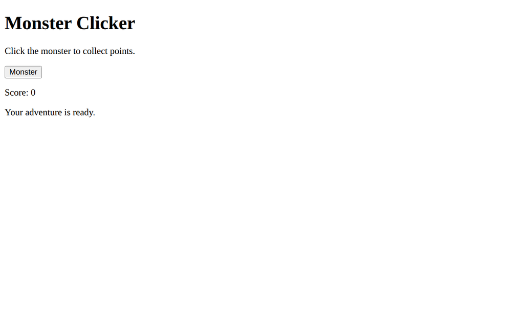

The complete Monster Clicker HTML rendered in a browser with default styling.

```html
<!doctype html>
<html lang="en">
<head>
  <meta charset="utf-8">
  <meta name="viewport" content="width=device-width, initial-scale=1">
  <title>Monster Clicker</title>
</head>
<body>
  <h1>Monster Clicker</h1>
  <p>Click the monster to collect points.</p>
  <button id="monster" class="monster" type="button">Monster</button>
  <p>Score: <span id="score">0</span></p>
  <p id="message">Your adventure is ready.</p>
</body>
</html>
```

The page uses the browser’s default appearance. Clicking the button does not increase the score. For this stage, success means the planned parts exist and appear in a useful reading order.

| Document piece | Job |
| --- | --- |
| `<!doctype html>` | Declare modern HTML; this is a declaration, not an element. |
| `<html lang="en">` | Hold the document and identify its language. |
| `<head>` | Hold information about the page. |
| `<meta charset="utf-8">` | Let the browser read the page’s text encoding. |
| Viewport `<meta>` | Set up the page for different screen widths. |
| `<title>` | Name the browser tab; it does not create the visible heading. |
| `<body>` | Hold the content people see and use. |

`<meta>` is a **void element**: it has no closing tag. The other elements here need closing tags. HTML comments, such as `<!-- My scene plan -->`, are notes for the code reader and do not appear as page text.

## 3.5 Group and nest the parts

**Nesting** means putting one element inside another. In this page, the visible elements are children of `<body>`. The score paragraph contains a `<span>` for the number. The heading, instructions, button, score paragraph, and message paragraph are siblings because they share the same parent.

Inside the score paragraph, `<span id="score">0</span>` marks just the number. A later program can change that number without replacing the words `Score:`. Close an inner element before closing its parent. Indentation helps you read these relationships; spaces alone do not create them.

| HTML tool | Use it for | Small example |
| --- | --- | --- |
| `<h1>` | Main heading | `<h1>Monster Clicker</h1>` |
| `<p>` | A paragraph or short status | `<p>Ready!</p>` |
| `<span>` | A small part within a line | The score number |
| `<button>` | A control the player can press | The monster target |
| `id`, `class` | Identify one part; group parts for styling | `id="score"`, `class="monster"` |

## Exercises

### Exercise 1: Find the relationships

**Flow focus:** Structure: explain the parts and their nesting.

Draw a tree showing `<body>`, the monster button, the score paragraph, and the score span. Which element contains the score span? Which elements are siblings?

### Exercise 2: Fix the grouping

**Flow focus:** Structure: close inner elements before outer ones.

Correct this fragment, then explain the problem:

```html
<p>Score: <span>0</p></span>
```

### Exercise 3: Add one visible part

**Flow focus:** Structure: extend the page without adding appearance rules or game code.

Add a paragraph showing `Lives: 3`. Give just the number a unique ID. Save, refresh, and verify that the score still has its own ID.

### Exercise 4: Make a tiny pitch

Write: “You are *, and your goal is to* by ___.” Circle the objects your page will need to show. If your sentence needs several kinds of controls or many levels, choose just one action for the first version.

### Exercise 5: Test your sketch

Ask a partner to point to the game name, the target, and the place where progress will appear. If a part is missing, add it. A paper sketch checks the arrangement; it does not test browser code.

### Exercise 6: Read before editing

Find the monster button in the HTML example earlier in this chapter. Point to its opening tag, closing tag, content, attribute names, and values. Change only its visible text to `Sleepy Monster`. Predict which part of the page will change.

### Exercise 7: Compare title and heading

Change `<title>` to `My First Game`. Save and refresh. Then change `<h1>` to `Sleepy Monster`. Explain why these changes appear in different places.

### Exercise 8: Add an instruction list

Place this list after the instructions paragraph. `<ul>` creates a bulleted list; each `<li>` creates one item.

```html
<ul>
  <li>Find the monster.</li>
  <li>Watch the score.</li>
</ul>
```

Add a third item. Check that it appears inside the same list. For a numbered sequence, use `<ol>` in place of `<ul>`.

## Challenge: Your own game scene

**Structure:** Change the title, instructions, and target to fit your tiny pitch. Add one useful display. **Style:** Keep browser defaults for now and check the reading order. **Behavior:** Write one future action and expected result in your notes.

# 4 Style: Make the Scene Readable

STYLE 04 | Monster Clicker: a few simple changes CSS Selectors Box model

## Overview

Your Chapter 3 page already has the parts of Monster Clicker. Now use **CSS** to change just three of them: the heading, the monster button, and the message. Keep the browser’s usual appearance for everything else.

In **Structure → Style → Behavior**, style helps players recognize the parts and read the page. Making the button purple does not make it count points; the behavior lessons will connect that action.

## Learning Objectives

By the end of this chapter, you will be able to:

- connect a stylesheet to an HTML page;
- read a simple CSS rule and choose an element to style;
- explain content, padding, border, and margin;
- change a few parts of a page and check the result.

## 4.1 Connect a stylesheet

Create `styles.css` beside your Chapter 3 `index.html`. Add this line inside `<head>`, after `<title>`:

```html
<link rel="stylesheet" href="styles.css">
```

`href` tells the browser where to find the stylesheet. Save both files and refresh the page after a change.

The general syntax of a CSS rule is:

```
selector {
  property: value;
}
```

The **selector** chooses HTML elements. The **property** (style key) names the appearance to change, and the **value** says how to change it. A rule can contain several property–value pairs between its braces.

Start with one rule in `styles.css`:

```css
h1 {
  color: purple;
}
```

`h1` is the **selector**: it chooses the main heading. Inside the braces, `color` is the **property** and `purple` is its **value**. The colon separates them; the semicolon ends the declaration. This rule makes the heading text purple.

## 4.2 Choose only the parts you want to change

We will use three selectors from the existing HTML:

| Selector | Chooses | HTML it matches |
| --- | --- | --- |
| `h1` | Main headings | `<h1>Monster Clicker</h1>` |
| `.monster` | Elements with the class `monster` | `<button class="monster" ...>` |
| `#message` | The element with the ID `message` | `<p id="message">...</p>` |

A dot selects a **class**; a `#` selects an **ID**. Write those symbols in CSS, not in the HTML attribute values. A class can be shared by several elements; an ID identifies one element on the page.

## 4.3 Understand the box model

Think of an element as a box with four layers:

[figure not shown]

The CSS box model: content is surrounded by padding, a border, and margin.

| Layer | Meaning | On our monster button |
| --- | --- | --- |
| **Content** | The text or picture inside the element. | The word Monster. |
| **Padding** | Space between the content and its border. | Room inside the button around its label. |
| **Border** | The line around the padded content. | An indigo outline around the button. |
| **Margin** | Space outside the border. | A gap between the button and nearby parts. |

**Padding makes room inside; margin makes room outside.** The border sits between them. The diagram colors label the layers; margin itself is transparent.

We will use `padding: 16px`, `border: 3px solid indigo`, and `margin: 8px` on the monster button. `px` means pixels. One padding or margin value applies to all four sides. The border declaration gives its thickness, line style, and color.

## 4.4 Style three parts of the game

Replace the contents of `styles.css` with this complete short stylesheet:

```css
h1 {
  color: purple;
}
.monster {
  font-size: 32px;
  color: white;
  background: purple;
  padding: 16px;
  border: 3px solid indigo;
  margin: 8px;
}
#message {
  color: darkgreen;
}
```

The arrows below connect each CSS selector to the line of HTML it styles in the companion style page. The stylesheet line numbers match the complete CSS example above.

[figure not shown]

CSS selectors pointing to their matching HTML lines.

[figure not shown]

Structure: HTML only, before CSS or JavaScript.

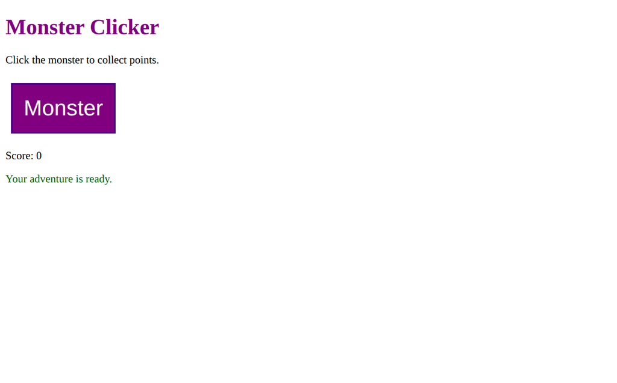

Style: the same HTML with CSS applied; JavaScript is still off.

The heading becomes purple. The monster button gets larger text, white letters on purple, and space inside and outside its border. The message becomes dark green. The instructions, score, and page arrangement keep their browser defaults.

Save, refresh, and compare the two views. Press Tab to find the monster button: the browser still supplies its normal keyboard focus indicator. Pressing the button leaves the score at zero because this page has no scoring rule yet.

## Exercises

### Exercise 1: Read a rule

In `h1 { color: purple; }`, name the selector, property, and value. Which part of the page changes?

### Exercise 2: Padding or margin?

Change only the button’s padding from `16px` to `24px`. Save and refresh. Notice the space inside the border. Restore it, then change only the margin from `8px` to `24px`. Which outside gap changes?

### Exercise 3: Change the border

Change the button’s border from `3px solid indigo` to `5px solid darkgreen`. Predict what will change, then check. Does the score rule change too?

### Exercise 4: Fix a selector

A friend writes `monster { background: purple; }`, but the button has `class="monster"`. Fix the selector and explain why the dot matters.

## Challenge: Make a few useful changes

**Structure:** Reuse your Chapter 3 page. **Style:** Change the heading color, button padding, and message color. Keep the text readable and use Tab to find the button. **Behavior:** Check that the score still stays at zero.

Use the HTML/CSS reference when a later game needs more styling tools.

# 5 Behavior: Plan Actions and Game Rules

BEHAVIOR 05 | Monster Clicker: the action plan Input State Rules Feedback Testing

## Overview

Your scene has parts and a readable style. It still needs rules that connect player actions to changes. This chapter introduces **behavior** using small examples, a paper simulation, and browser controls. You will describe what should happen before learning the JavaScript that implements it.

Keep the same Monster Clicker page. In **Structure → Style → Behavior**, your next question is **“What happens when the player acts?”** Chapter 6 will prepare game memory; Chapter 7 will connect clicks to that memory and the page.

Open the companion behavior example to inspect this stage. The chapter shows you how to build your own copy.

## Learning Objectives

By the end of this chapter, you will be able to:

- distinguish appearance from programmed game behavior;
- describe input, remembered state, a rule, and visible feedback;
- predict an action’s result and check it with a paper simulation;
- add labeled input controls and explain their native browser behavior;
- plan a restart rule and choose the stage to revisit after a test.

## 5.1 Describe one action and result

Start with one rule in ordinary words:

> When the player hits the monster, increase the score by one and show a message.

A **behavior** describes what the game does when something happens. **Input** is information from the player, such as a click, key press, or choice. **State** is information the game remembers. A **rule** decides how that state changes. **Feedback** shows or communicates the result.

| Part of the action | Monster Clicker example |
| --- | --- |
| Input | The player presses the monster button. |
| State before | The score is zero. |
| Rule | Add one point for one hit. |
| State after | The score is one. |
| Feedback | Show the new score and a hit message. |

Changing the button’s color is a style change. Changing how many points a hit earns is a behavior change. Adding a new score display is a structure change. One feature may need all three responsibilities.

## 5.2 Run the rule on paper

Draw the monster, score, and message on a sheet of paper. Write `0` in the score area. One person is the player; another carries out the rule exactly as written.

1. The player points to the monster to represent a hit.
2. The rule keeper adds one to the remembered score.
3. The rule keeper writes the new score and a message.
4. Repeat the action twice more.

| Action | Score before | Rule | Score after |
| --- | --- | --- | --- |
| First hit | 0 | Add 1 | 1 |
| Second hit | 1 | Add 1 | 2 |
| Third hit | 2 | Add 1 | 3 |

This makes the expected results explicit. It does not prove that the browser will receive a click or that future code is correct. It gives you a rule and test cases for that code.

## 5.3 Choose controls for player input

```html
<p>
  <label for="player-name">Player nickname</label>
  <input id="player-name" name="player-name" type="text" value="Game Maker">
</p>
```

`<label>` names the control. Its `for` value matches the input’s unique `id`. Clicking the label focuses the field. `type="text"` chooses a text box, `value` supplies its initial value, and `name` identifies the field for form data. `<input>` is a void element.

Your future rule could be: “When a round starts, read the nickname and use it in the welcome message.” Typing a name alone does not implement that rule.

### Add a choice menu

```html
<p>
  <label for="difficulty">Choose a mode</label>
  <select id="difficulty" name="difficulty">
    <option value="easy">Easy</option>
    <option value="hard">Hard</option>
  </select>
</p>
```

`<select>` creates the menu. Each `<option>` supplies a choice; its `value` is the data associated with that choice. Selecting Hard changes the menu’s selected value. It does not automatically change a game’s difficulty. Your program must read the choice and apply a rule.

### Add an on/off choice

```html
<p>
  <label><input id="sound" type="checkbox" checked> Sound on</label>
</p>
```

These views show all three controls together in the companion scene. Typing and selecting use built-in browser behavior; the game’s scoring rules are still a plan.

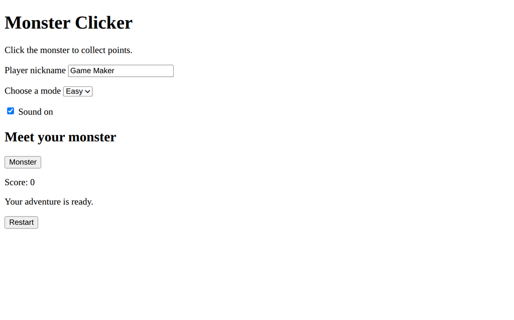

Structure: HTML only, before CSS or JavaScript.

[figure not shown]

Style: the same HTML with CSS applied; JavaScript is still off.

[figure not shown]

Native controls: the nickname, mode, and sound choices before editing. The game rules are still a plan.

[figure not shown]

Native controls after typing Maya, choosing Hard, and turning Sound off. These controls do not yet change the score.

A checkbox toggles on or off. Putting it inside its label also connects the label and control. `checked` is a Boolean attribute: its presence sets the initial checked state. Write it without `="false"`; that text would still leave the attribute present.

| Control | Native browser response | Game behavior to program later |
| --- | --- | --- |
| Text input | Accept typing | Use the nickname in the game. |
| Select menu | Change the selected option | Apply the chosen mode’s rules. |
| Checkbox | Toggle checked state | Enable or disable game sound. |
| Button with `type="button"` | Accept focus and activation | Start, hit, or restart according to your rule. |

These native responses make the controls usable. They are different from your programmed game operations. The reference appendix covers forms and extra controls such as sliders and color inputs when a later task needs them.

## 5.4 Plan conditions, goals, and reset

A story gives the action meaning; a rule gives it an exact result. For example, “Wake the sleepy monster” is a story goal. “After five points, display ‘Awake!’” is a testable rule.

| Situation to test | Expected result for this small plan |
| --- | --- |
| Open the page | Score begins at zero; a ready message appears. |
| Hit once | Score increases by one. |
| Reach five points | Message shows `Awake!`. |
| Hit again | Decide whether play continues or ends; write that rule first. |
| Restart | Restore score zero and the ready message. |

Choose one clear end rule. If five points ends the round, later hits should not earn points until restart. If play continues, the score can keep growing. Neither choice comes automatically from the HTML or CSS.

The repeated player activity—hit, see progress, decide to hit again—is a **core play loop**. It describes play. The later animation loop describes repeating work in code; the two ideas have different jobs.

## 5.5 Connect and test all three stages

Use the full guide now that you have practiced each responsibility separately:

**Build the scene structure → Style the scene → Program game behavior.**

[figure not shown]

Build one feature through Structure, Style, and Behavior, then playtest and improve it.

**Read the arrows:** Begin with one small feature based on your idea and rules. Follow the solid arrows and check each stage. The dashed arrow means that a test revealed a needed change. Return to the responsible stage, then recheck the stages that depend on it. Reuse what already meets the task.

For a gem-collection feature, **Structure** supplies a gem, a count, and a collected/not-collected state. **Style** makes the gem and count recognizable. **Behavior** removes an uncollected gem and increases the count only once.

Predict the result before trying an action. If the counter is missing, revisit Structure. If it is hard to read, revisit Style. If one gem earns points twice, investigate Behavior. After the change, test the complete collection action again.

Use simple shapes and readable labels first; finished artwork can wait. A new behavior may need another control or display. This is a development strategy, separate from browser file-loading order.

## Exercises

### Exercise 1: Predict a sequence

**Flow focus:** Behavior: apply a rule to remembered state.

Start at zero and add two points for each hit. Predict the score after four hits. Then simulate the actions on paper and compare the results.

### Exercise 2: Choice or game rule?

**Flow focus:** Structure + Behavior: distinguish a control’s value from the rule that uses it.

A player chooses Hard, but the game still awards one point per hit. Explain why adding a menu is not enough to change that rule. Write one possible rule for Hard mode.

### Exercise 3: Test restart

**Flow focus:** Behavior: restore a known starting state.

A game restarts with score zero but still says `Awake!`. Describe the missing reset operation and a test that would reveal the problem.

### Exercise 4: Separate the responsibilities

Classify these changes: add a lives display; give the display more spacing; reduce lives after a missed action. Name each stage and explain your choice.

### Exercise 5: Change one rule

Make each hit earn two points instead. Predict the first three scores before simulating them. Which page elements and CSS rules can remain unchanged?

### Exercise 6: Check the label connection

Click the label, type a nickname, and use Tab to move away. Check that the text field received focus. Temporarily misspell the label’s `for` value, observe what changes, and restore it.

### Exercise 7: Add a restart control

Add `<button id="restart" type="button">Restart</button>` after the message. Give it a little margin using Chapter 4’s approach, then use Tab to check the browser’s keyboard focus indicator. Write the values and messages that Restart should restore. Pressing it does not run that plan yet; the event lesson will connect it.

## Challenge: Your action plan

**Structure:** Reuse your scene and add only the controls or displays your idea needs. **Style:** Make them readable and test their focus. **Behavior:** Write three action/result pairs, an end rule, and a restart rule. Simulate one successful action, one boundary case, and one restart.

# 6 Teach the Game to Remember

GAME 06 | Monster Clicker Starter

Variables Data Types Arrays Objects

## Overview

Keep using our development flow:

**Build the scene structure → Style the scene → Program game behavior.**

First use HTML to build what the player sees and uses. Next use CSS to make that scene readable. Then use JavaScript to implement the game’s operations and actions. This chapter begins the behavior stage by giving those actions **data and memory**; Chapter 7 connects them to clicks.

Before a game can react to a player, it needs something very important: **memory**.

A game may need to remember:

- the player’s score;
- the player’s name;
- the number of lives left;
- whether the game has started;
- which treasures have been collected;
- information about the player or a monster.

JavaScript stores these values in **variables**.

In this chapter, you will build the starting version of a **Monster Clicker** project. The monster will appear on the page, and JavaScript will create the data the game needs. The monster will not react to a click yet. In Chapter 7, you will connect this same project to the page and make the monster clickable.

`{mermaid} flowchart LR A[Chapter 6<br/>Create game data] --> B[score, name, lives, inventory] B --> C[Chapter 7<br/>Connect JavaScript to the page] C --> D[Click the monster<br/>and update the game]`

The Main Idea

Chapter 6 answers this question:

**What information should the game remember?**

Chapter 7 will answer the next question:

**How does JavaScript react when the player clicks something on the page?**

## Learning Objectives

By the end of this chapter, you will be able to:

- apply **Build the scene structure → Style the scene → Program game behavior** when building the starter;
- explain why games need variables;
- declare variables with `let`, `const`, and `var`;
- choose between `let` and `const` in simple programs;
- recognize number, string, Boolean, and `undefined` values;
- explain that JavaScript uses the `Number` type for both whole and decimal numbers;
- create an array to store a list of values;
- create an object to store related key-value pairs;
- change the value stored in a variable;
- build the starting data for the Monster Clicker project that will continue in Chapter 7.

## 6.1 Think through the Monster Clicker before coding

| Development step | Decision for our game | Check |
| --- | --- | --- |
| 1. Build the scene structure | Show a title, monster button, message, and score inside a main card. | All four parts exist; `monster`, `message`, and `score` have distinct IDs. |
| 2. Style the scene | Reuse Chapter 4’s button colors, border, and spacing; this example also adds a card around the scene. | The monster and score are easy to find; the button has a visible keyboard focus ring. |
| 3. Program game behavior | Plan a hit that raises the score and changes the message. Prepare score, lives, treasures, and player data first. | Inspect the starting values in the console. The hit action is implemented in Chapter 7. |

For every JavaScript example in this chapter, ask **which future operation needs this value?** A score supports counting hits. Lives support tracking remaining chances. A Boolean supports a running/not-running decision. An array supports a treasure collection. An object groups player information. These small examples practice the memory part of Step 3; they do not each need a new page or stylesheet.

When a practice task changes only data, keep the existing structure and style and work on that one behavior preparation. When a task needs a new visible part, return to structure, style the new part, and then connect its behavior.

## 6.2 A Variable Gives a Value a Name

Imagine that your game has a score of `0`.

You could write:

```javascript
0
```

But this number does not explain what it means. Is it the score? The number of lives? The level number?

Instead, we give the value a useful name:

```javascript
let score = 0;
```

A **variable** is a named place where a program keeps a value.

`{mermaid} flowchart LR A[Variable name<br/>score] --> B[Stored value<br/>0]`

Read this line in pieces:

```javascript
let score = 0;
```

- `let` tells JavaScript to create a variable.
- `score` is the variable’s name.
- `=` means **assign** or **store**.
- `0` is the value being stored.
- `;` marks the end of the statement.

Understand `=`

In JavaScript, `=` means **assignment**.

```javascript
score = 5;
```

means:

**Store the value `5` in `score`.**

It does not mean mathematical equality.

### Use meaningful names

Compare these two variables:

```javascript
let x = 0;
```

```javascript
let score = 0;
```

Both work, but `score` tells us what the value means.

Game variables might have names such as:

```javascript
let score = 0;
let lives = 3;
let level = 1;
let playerSpeed = 5;
```

JavaScript variable names cannot contain spaces. For names with several words, JavaScript programmers often use **camelCase**:

```javascript
let playerName = "Maya";
let monsterHealth = 10;
let treasureCount = 0;
```

The first word starts with a lowercase letter. Each later word begins with a capital letter.

## 6.3 Variables Can Store Different Kinds of Values

Games need to remember more than scores. A game might remember a name, a speed, whether a door is open, or a list of treasures.

The kind of value stored in a variable is called its **data type**.

### Numbers

JavaScript uses the type `Number` for ordinary numbers.

```javascript
let score = 7;
let lives = 3;
let speed = 2.5;
```

`7` and `3` are whole-number values. They are often called **integers**.

`2.5` contains a decimal part. It is often called a **floating-point** or decimal value.

But JavaScript does not normally separate these into `int` and `float` variable types. Both are JavaScript numbers.

```javascript
console.log(typeof 7);    // number
console.log(typeof 2.5);  // number
```

JavaScript Is Different from Some Languages

In languages such as Java or C++, you may see declarations using types such as `int`, `float`, or `double`.

In JavaScript, both of these are ordinary `Number` values:

```javascript
let hits = 7;
let speed = 2.5;
```

### Strings

A **string** stores text.

```javascript
let playerName = "Maya";
let monsterName = "Pixel Beast";
let message = "Get ready!";
```

String values go inside quotation marks.

Compare:

```javascript
let score = 7;     // Number
let label = "7";   // String
```

They look similar, but JavaScript treats them as different kinds of values.

### Boolean values

A **Boolean** has only two possible values:

```javascript
true
false
```

For example:

```javascript
let gameStarted = false;
let monsterVisible = true;
```

Booleans are useful for yes-or-no game states:

- Is the game running?
- Is the player alive?
- Is the door open?
- Has the treasure been collected?

Do not put quotation marks around a Boolean value:

```javascript
let gameStarted = true;    // Boolean
let word = "true";         // String
```

### `undefined`: no value yet

A variable can exist before a useful value has been stored in it.

```javascript
let playerChoice;
```

At this point, the value is `undefined`.

For beginner programs, it is usually easier to give variables a useful starting value:

```javascript
let score = 0;
let playerName = "";
let gameStarted = false;
```

## 6.4 Changing a Variable

The most useful game values usually change while the game runs.

Start with:

```javascript
let score = 0;
```

Later, the game can store a new value:

```javascript
score = 1;
```

Then another:

```javascript
score = 2;
```

The variable name stays `score`, but the stored value changes.

`{mermaid} flowchart LR A[score = 0] --> B[score = 1] B --> C[score = 2] C --> D[score = 3]`

```javascript
score = score + 1;
```

Read it from right to left:

1. read the current value of `score`;
2. add `1`;
3. store the new value back in `score`.

If `score` begins at `0`, then:

```javascript
score = score + 1;
```

changes it to `1`.

Run it again, and the value becomes `2`.

Try It in the Console

Try:

```javascript
let score = 0;
console.log(score);

score = score + 1;
console.log(score);

score = score + 1;
console.log(score);
```

Predict all three outputs before running the code.

Advanced Study: A Shorter `+ 1`

JavaScript also lets you write:

```javascript
score++;
```

For now, `score = score + 1` is easier to read because it shows all three steps: read, add, and store. You will see `++` again when loops are introduced later.

## 6.5 Three Ways to Declare Variables: `let`, `const`, and `var`

JavaScript has three declaration keywords you will commonly see:

```javascript
let score = 0;
const gameTitle = "Monster Clicker";
var oldStyleScore = 0;
```

They all create names, but they are not used in exactly the same way.

### Use `let` when the value will be reassigned

A score changes, so `let` is a good choice:

```javascript
let score = 0;
score = 1;
score = 2;
```

Other common game examples are:

```javascript
let lives = 3;
let level = 1;
let gameStarted = false;
```

### Use `const` when the variable should keep the same value or reference

Some names do not need to point to a different value.

```javascript
const gameTitle = "Monster Clicker";
const maxLives = 3;
```

You cannot reassign a `const` variable:

```javascript
const maxLives = 3;
maxLives = 5; // Error
```

A useful beginner rule is:

> Use `const` when you do not plan to reassign the variable. Use `let` when you know the stored value must be replaced later.

### What is `var`?

Older JavaScript programs often use `var`:

```javascript
var score = 0;
```

`var` was the traditional way to declare JavaScript variables before `let` and `const` were added to the language.

You should recognize it because you may see it in older tutorials and programs.

For the games in this book, we will usually prefer `let` and `const`.

| Declaration | Beginner use in this book | Example |
| --- | --- | --- |
| `let` | the variable will be reassigned | `let score = 0;` |
| `const` | the variable should keep the same value/reference | `const gameTitle = "Monster Clicker";` |
| `var` | recognize older JavaScript code | `var score = 0;` |

Book Rule

When writing new code:

1. Ask: **Will I reassign this variable later?**
2. If yes, use `let`.
3. If no, use `const`.
4. Recognize `var`, but you usually do not need to choose it for new code in this book.

Advanced Study: Why Modern JavaScript Prefers `let` and `const`

`let` and `const` use **block scope**. A variable created inside a `{ }` block belongs to that block.

```javascript
{
  let bonus = 5;
  console.log(bonus);
}

// bonus cannot be used here
```

`var` follows older scoping rules and does not behave the same way inside blocks. You do not need to master scope yet, but this difference is one reason modern JavaScript usually uses `let` and `const`.

## 6.6 Arrays Store a List of Values

Suppose the Monster Clicker game can award several treasures:

- a coin;
- a gem;
- a key.

You could create three variables:

```javascript
const treasure1 = "coin";
const treasure2 = "gem";
const treasure3 = "key";
```

But these values belong together. An **array** stores a list in one variable.

```javascript
const treasures = ["coin", "gem", "key"];
```

Square brackets `[` and `]` mark the array. Commas separate the items.

`{mermaid} flowchart LR A[treasures] --> B[0: coin] A --> C[1: gem] A --> D[2: key]`

Each item has a numbered position called an **index**.

JavaScript starts array indexes at `0`:

```javascript
console.log(treasures[0]); // coin
console.log(treasures[1]); // gem
console.log(treasures[2]); // key
```

So the first item is at index `0`, not index `1`.

### An array can change even when declared with `const`

Start with an inventory:

```javascript
const inventory = ["map"];
```

Add another item:

```javascript
inventory.push("key");
```

Now the array contains:

```
map, key
```

This is allowed because `const` keeps the variable from being reassigned to a different array. It does not freeze the contents of the array.

This is allowed:

```javascript
const inventory = ["map"];
inventory.push("key");
```

This is not:

```javascript
const inventory = ["map"];
inventory = ["gem"]; // Error
```

You can also check how many items an array contains:

```javascript
console.log(inventory.length);
```

## 6.7 Objects Store Related Information with Keys

An array is useful for an ordered list. Sometimes, however, each value needs a name.

Imagine that the Monster Clicker player has a name, score, and lives:

```javascript
const player = {
  name: "Maya",
  score: 0,
  lives: 3
};
```

This is an **object**.

An object stores related information as **key-value pairs**.

`{mermaid} flowchart LR A[player] --> B[name → Maya] A --> C[score → 0] A --> D[lives → 3]`

In this object:

- `name` is a key and `"Maya"` is its value;
- `score` is a key and `0` is its value;
- `lives` is a key and `3` is its value.

You can read an object property with a dot:

```javascript
console.log(player.name);
console.log(player.score);
```

You can also change a property:

```javascript
player.score = 1;
```

Even though `player` was declared with `const`, changing one of its properties is allowed. The variable still refers to the same object.

Array or Object?

Use an **array** when you mainly need an ordered list:

```javascript
const treasures = ["coin", "gem", "key"];
```

Use an **object** when each piece of information needs a descriptive key:

```javascript
const player = {
  name: "Maya",
  score: 0,
  lives: 3
};
```

Advanced Study: Object and `Map` Are Not the Same Thing

A JavaScript object can be used like a simple key-value collection, but JavaScript also has a separate built-in type called `Map`.

`Map` is a later topic. For now, objects are enough for storing small groups of named game information.

## 6.8 Build the Monster Clicker Starter

Now use the ideas from this chapter to start a project that will continue in Chapter 7.

At the end of this chapter, your game will have:

- a monster on the page;
- a place for a message;
- a place where the score will eventually appear;
- JavaScript variables that describe the game;
- an inventory array;
- a player object.

The monster will **not respond to clicks yet**. That is intentional.

Chapter 7 will introduce the missing ideas: how JavaScript finds HTML elements and how **events** tell the program that the player clicked something.

### Step 1: Build the scene structure — build the HTML game board

Sketch the title, monster, message, and score first. Create a file such as `monster-clicker.html`, or continue the scene from Chapters 3–5. Keep the script as a placeholder while checking this first stage:

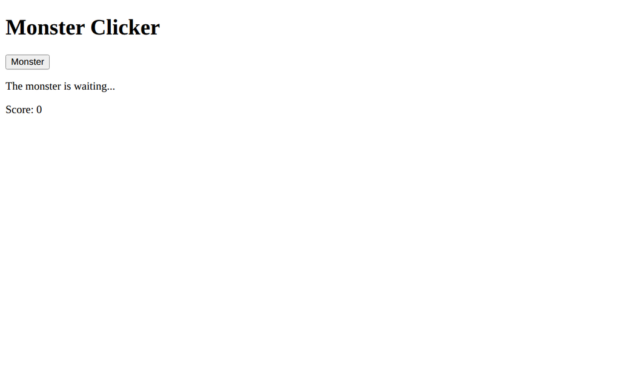

The Monster Clicker starter after Step 1: the HTML provides the page content with the browser’s default styling.

```html
<!doctype html>
<html lang="en">
<head>
  <meta charset="utf-8">
  <meta name="viewport" content="width=device-width, initial-scale=1">
  <title>Monster Clicker</title>
  <style>
    /* Step 2: Style the scene rules will go here. */
  </style>
</head>
<body>
  <!-- Step 1: Build the scene structure (page structure). -->
  <main class="card">
    <h1>Monster Clicker</h1>
    <button id="monster" class="monster" type="button">Monster</button>
    <p id="message">The monster is waiting...</p>
    <p id="score">Score: 0</p>
  </main>

  <script>
    // Step 3: Program game behavior — prepare data; click actions come in Chapter 7.
  </script>
</body>
</html>
```

Notice these IDs:

```html
id="monster"
id="message"
id="score"
```

Do not write JavaScript to use them yet. Keep them in the page because **Chapter 7 will show how JavaScript uses an element’s `id` to find that exact element**.

`{mermaid} flowchart LR A[id="monster"] --> B[Monster button] C[id="message"] --> D[Message paragraph] E[id="score"] --> F[Score paragraph]`

A Preview for Chapter 7

The `id` values are like unique labels attached to HTML elements.

In Chapter 7, JavaScript will use those labels to find the monster, message, and score on the page.

### Step 2: Style the scene — reuse the page design

The structure is ready. Put this familiar CSS inside the head’s `<style>` element, replacing its placeholder comment. This builds on Chapter 4’s colors and spacing with a few extra rules for the game card; the shared `.monster` class will also work when you add more monsters later.

```css
* { box-sizing: border-box; }
body {
  margin: 0;
  min-height: 100vh;
  display: grid;
  place-items: center;
  background: #eef7ff;
  color: #17243b;
  font-family: system-ui, sans-serif;
}
.card {
  width: min(92%, 620px);
  padding: 24px;
  border: 3px solid #17243b;
  border-radius: 20px;
  background: white;
}
.monster {
  padding: 18px;
  border: 2px solid #17243b;
  border-radius: 14px;
  background: #e7dcff;
  font: inherit;
  cursor: pointer;
}
.monster:focus-visible {
  outline: 4px solid #ffe48a;
  outline-offset: 2px;
}
#message { min-height: 1.5em; }
```

[figure not shown]

The same starter after Step 2: CSS centers a white card on a pale blue background and styles the monster button.

Save and refresh. Check the card, monster, message, and score before adding JavaScript. If you continued your styled scene, you can instead keep its linked `styles.css`; the development step is the same. This chapter embeds CSS only to keep the complete example in one file.

### Step 3: Program game behavior — prepare memory for game actions

Write the intended rule first: **When the monster is hit, add one to the score and update the message.** That action needs a score to remember between hits. Prepare the starting data now; Chapter 7 will implement the event and display changes. Styling a button does not connect that operation.

The substeps below all belong to this behavior-preparation stage.

#### Prepare the basic game variables

Inside the `<script>` block, add:

```javascript
const gameTitle = "Monster Clicker";
const monsterName = "Pixel Beast";

let score = 0;
let lives = 3;
let gameStarted = false;
```

Why are the declarations different?

```javascript
const gameTitle = "Monster Clicker";
const monsterName = "Pixel Beast";
```

These values are not expected to be reassigned during this simple game, so `const` is a good choice.

```javascript
let score = 0;
let lives = 3;
let gameStarted = false;
```

These values may change while the game runs, so `let` is a good choice.

#### Prepare a treasure list

Add an array:

```javascript
const treasures = ["coin", "gem", "key"];
```

Later, the game could choose one of these rewards when the monster is hit.

For now, inspect the values in the browser console:

```javascript
console.log(treasures[0]);
console.log(treasures[1]);
console.log(treasures[2]);
```

#### Group player information in an object

Add:

```javascript
const player = {
  name: "Maya",
  score: 0,
  lives: 3
};
```

Then try:

```javascript
console.log(player.name);
console.log(player.score);
console.log(player.lives);
```

This object shows another way the game could organize related data.

For the first version of Monster Clicker, Chapter 7 will continue to use the simpler variable:

```javascript
let score = 0;
```

That keeps the first event example easy to follow. The `player` object gives you a preview of how larger games can organize several related values together.

Before a click can change the score automatically, you can change the variable yourself:

```javascript
console.log(score); // 0

score = score + 1;
console.log(score); // 1

score = score + 1;
console.log(score); // 2
```

The number on the web page still says:

```
Score: 0
```

Why?

Because the JavaScript variable and the HTML paragraph are not connected yet.

`{mermaid} flowchart LR A[JavaScript memory<br/>score = 2] -. not connected yet .-> B[HTML display<br/>Score: 0]`

This is the exact problem Chapter 7 will solve.

Important: Memory and Display Are Different

The variable:

```javascript
let score = 0;
```

stores information in JavaScript memory.

The HTML:

```html
<p id="score">Score: 0</p>
```

displays text on the page.

Changing one does not automatically change the other. In Chapter 7, you will learn how JavaScript finds the paragraph and updates it.

## 6.9 Complete Chapter 6 Starter Code

Read this complete example in our development order: locate the **scene structure** in the body, then its **style** in the head, then the data preparing its **behaviors** in the script. The head comes before the body in HTML file order; that does not change the thinking strategy. A runnable copy is in `workspace/chapter3/starter.html`.

```html
<!doctype html>
<html lang="en">
<head>
  <meta charset="utf-8">
  <meta name="viewport" content="width=device-width, initial-scale=1">
  <title>Monster Clicker</title>
  <style>
    /* Step 2: Style the scene. */
    * { box-sizing: border-box; }
    body {
      margin: 0;
      min-height: 100vh;
      display: grid;
      place-items: center;
      background: #eef7ff;
      color: #17243b;
      font-family: system-ui, sans-serif;
    }
    .card {
      width: min(92%, 620px);
      padding: 24px;
      border: 3px solid #17243b;
      border-radius: 20px;
      background: white;
    }
    .monster {
      padding: 18px;
      border: 2px solid #17243b;
      border-radius: 14px;
      background: #e7dcff;
      font: inherit;
      cursor: pointer;
    }
    .monster:focus-visible {
      outline: 4px solid #ffe48a;
      outline-offset: 2px;
    }
    #message { min-height: 1.5em; }
  </style>
</head>
<body>
  <!-- Step 1: Build the scene structure (page structure). -->
  <main class="card">
    <h1>Monster Clicker</h1>
    <button id="monster" class="monster" type="button">Monster</button>
    <p id="message">The monster is waiting...</p>
    <p id="score">Score: 0</p>
  </main>

  <script>
    // Step 3: Program game behavior — prepare data; click actions come in Chapter 7.
    const gameTitle = "Monster Clicker";
    const monsterName = "Pixel Beast";

    let score = 0;
    let lives = 3;
    let gameStarted = false;

    const treasures = ["coin", "gem", "key"];

    const player = {
      name: "Maya",
      score: 0,
      lives: 3
    };

    console.log(gameTitle);
    console.log(monsterName);
    console.log(score);
    console.log(treasures);
    console.log(player);
  </script>
</body>
</html>
```

[figure not shown]

Behavior preparation: JavaScript has initialized the game data; the page still shows Score: 0.

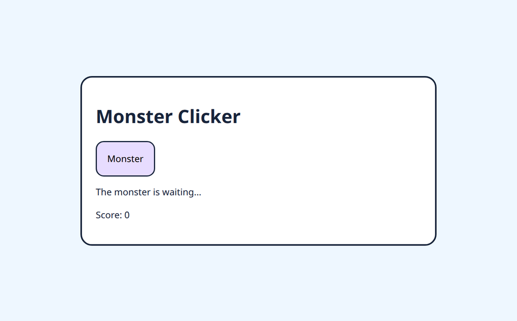

After a test click, Score: 0 and the waiting message remain unchanged. Chapter 7 adds the click listener.

When you open the page:

- the monster appears;
- the score display begins at `0`;
- JavaScript creates the game variables;
- clicking the monster does nothing yet.

That last point is not a bug. It marks your progress.

`{mermaid} flowchart TD A[Build the scene structure<br/>HTML page elements] --> S[Style the scene<br/>CSS presentation] S --> B[Program game behavior: Chapter 6<br/>Prepare game data and memory] B --> C[Program game behavior: Chapter 7<br/>Find page elements with the DOM] C --> D[Listen for clicks with events] D --> E[Update score and message]`

Save This Project for Chapter 7

Keep this exact file. In Chapter 7, you will extend it instead of starting over.

The next version will reuse:

- `id="monster"`;
- `id="message"`;
- `id="score"`;
- `let score = 0;`;
- the Monster Clicker theme.

You will add only the new DOM and event code needed to make the project interactive.

## Exercises

Use **Structure → Style → Behavior** as a check before each task. The focus below identifies the stage you are practicing. For reading or prediction tasks, trace or explain the result; you do not need a new page or visual redesign.

### Exercise 1: Name the parts of a declaration

**Flow focus:** Program game behavior: identify the memory a future score action will change; keep the existing scene and style.

Look at:

```javascript
let score = 0;
```

Identify:

1. the declaration keyword;
2. the variable name;
3. the assignment operator;
4. the starting value.

### Exercise 2: Choose `let` or `const`

**Flow focus:** Program game behavior: decide which values future actions can replace and which bindings stay fixed.

Choose the better declaration for each value.

1. A player’s score that changes after each hit.
2. The title `"Monster Clicker"`.
3. The current level, which can change.
4. An array named `treasures` that will remain the same array.
5. The maximum number of lives, which does not change.

### Exercise 3: Recognize `var`

**Flow focus:** Program game behavior: change the declaration style while preserving the value the game will remember.

You find this older code online:

```javascript
var score = 0;
```

Rewrite it using the declaration style used for a changing value in this book.

### Exercise 4: Identify the data type

**Flow focus:** Program game behavior: identify the kinds of data available to game operations.

For each value, identify whether it is a **Number**, **String**, or **Boolean**.

```javascript
10
2.5
"10"
"Pixel Beast"
true
false
```

### Exercise 5: Predict the score

**Flow focus:** Program game behavior: predict successive updates to memory before checking the output.

What is printed?

```javascript
let score = 0;
score = score + 1;
score = score + 1;
score = score + 1;
console.log(score);
```

Explain why.

### Exercise 6: Read an array

**Flow focus:** Program game behavior: identify which treasure a collection index selects.

Given:

```javascript
const treasures = ["coin", "gem", "key"];
```

What does each expression produce?

```javascript
treasures[0]
treasures[1]
treasures[2]
```

### Exercise 7: Read an object

**Flow focus:** Program game behavior: read related player values without changing the player scene or its style.

Given:

```javascript
const player = {
  name: "Maya",
  score: 4,
  lives: 2
};
```

What values are produced by:

```javascript
player.name
player.score
player.lives
```

### Exercise 8: Memory versus page display

**Flow focus:** Structure + Behavior: distinguish the visible score element from score memory; styling cannot connect them.

Suppose the page contains:

```html
<p id="score">Score: 0</p>
```

and JavaScript later runs:

```javascript
let score = 0;
score = score + 1;
```

Does the paragraph automatically change to `Score: 1`?

Explain your answer using the ideas of **JavaScript memory** and **HTML display**.

### Exercise 9: Change the score in memory

Run the score changes shown earlier in this chapter. Predict the value after each change and compare it with the web page’s `Score: 0` display. Explain why the displayed score stays at zero.

## Challenges

### Challenge 1: Customize Your Monster

**Structure:** Change the visible title and monster label. **Style:** Choose one readable button color or spacing change. **Behavior:** Customize the starting data and inspect it in the console; the hit action still waits for Chapter 7.

Use **Build the scene structure → Style the scene → Program game behavior**. First change the visible title and monster label. Next choose one button color or spacing change. Then change the starter data so that it uses your own:

- game title;
- monster name;
- starting number of lives;
- three treasure names.

Choose `let` or `const` for each variable and explain one of your choices.

### Challenge 2: Build a Better Player Object

**Structure:** Keep the existing player page and identify the player information it represents. **Style:** Keep the current page style; no new display is required for this exercise. **Behavior:** Add the player properties and print their values.

The scene structure and style are already in place. Continue **Step 3: Program game behavior** by preparing memory for a future player action. Extend the player object with two new properties, such as:

```javascript
level
speed
favoriteTreasure
monsterHits
```

Print the new properties in the console.

### Challenge 3: Grow the Inventory

**Structure:** Keep the monster scene and identify the collection of gathered treasures. **Style:** Keep the current scene style; use the console to inspect this small operation. **Behavior:** Add the inventory items, predict its length, and check the result.

Keep the scene structure and style. In the **behavior** stage, practice the operation “add treasure to inventory.” Start with:

```javascript
const inventory = [];
```

Use `push()` to add three items. Then print:

```javascript
inventory
inventory.length
```

Predict the length before you run the code.

### Challenge 4: Prepare One More Value for Chapter 7

**Structure:** Keep the monster and the feedback areas. **Style:** Keep their current readable style. **Behavior:** Describe the future hit action and prepare one value it will change.

Keep the scene structure and style. In the **behavior** stage, describe one future hit action, then add a variable that it might change when the monster is clicked in the next chapter. Examples include:

```javascript
let monsterHealth = 5;
let combo = 0;
let hits = 0;
```

Write one sentence explaining how a click event could change your variable later.

# 7 Make the Page React: DOM Elements and Click Events

GAME 07 | Click the Monster

DOM Events JavaScript

## Overview

In Chapter 4, you used **HTML** to put things on a page and **CSS** to change how they look. In Chapter 6, you learned how JavaScript stores values using variables such as `const` and `let`.

Now we can connect JavaScript to the web page itself. A game needs to know **which thing on the page** JavaScript should work with and **when something happens** to that thing.

Imagine a monster button on the screen. Two questions must be answered before JavaScript can make it part of a game:

1. **How can JavaScript find the monster on the page?**
2. **How can JavaScript know when the player clicks it?**

Those two questions introduce two of the most important ideas in browser programming:

- the **DOM**, which lets JavaScript find and change page elements;
- **events**, which let JavaScript react to things that happen.

`{mermaid} flowchart LR A[HTML creates the page] --> B[Browser builds the DOM] B --> C[JavaScript finds an element] D[Player clicks] --> E[Click event] E --> F[JavaScript reacts] F --> C`

By the end of this chapter, one ordinary web page will become your first interactive web game.

## Learning Objectives

By the end of this chapter, you will be able to:

- explain what an **HTML element** is;
- explain why the HTML `id` attribute gives JavaScript a way to identify one element;
- describe the DOM as the browser’s JavaScript-friendly representation of the page;
- connect `id="..."` in HTML to the string used by `document.getElementById("...")`;
- explain what an **event** is;
- distinguish normal top-to-bottom execution from **event-driven execution**;
- connect a `click` event to a JavaScript function with `addEventListener()`;
- trace the flow from **page setup → waiting → event → handler → DOM change**;
- recognize that keyboard, input, and other events follow the same event-listener pattern.

Structure → Style → Behavior

**Build the scene structure → Style the scene → Program game behavior.**

- **Build the scene structure:** Identify or add the character, buttons, images, and message elements with unique IDs.
- **Style the scene:** Keep controls recognizable and text readable; default browser styling is enough for a small test.
- **Behavior:** Find the elements, attach one event handler, and compare its actual response with your prediction.

Use this plan for the examples and exercises below. Reuse parts that already work; change only what the task needs. After each step, predict one result and check it.

## 7.1 From HTML Elements to DOM Elements

Start with a small page:

```html
<h1>Click the Monster!</h1>
<button id="monster">Monster</button>
<p id="message">Can you catch it?</p>
```

The browser shows three visible pieces:

- a heading;
- a button;
- a paragraph.

Each piece created by an HTML tag is an **HTML element**.

For example:

```html
<button id="monster">Monster</button>
```

This creates a button element. The attribute `id="monster"` gives that element a unique name on the page.

Understand

An **element** is one part of a web page. Headings, paragraphs, buttons, images, and input boxes are all examples of elements.

### The browser creates a page model

When the browser reads HTML, it does more than draw words and buttons on the screen. It also creates an organized representation of those elements in memory.

That representation is called the **Document Object Model**, usually shortened to **DOM**.

For beginners, you can think of the DOM as the browser’s **live map of the page**.

`{mermaid} flowchart TD D[document] --> H[h1: Click the Monster!] D --> B[button: monster] D --> P[p: message]`

The HTML file is the code you wrote. The DOM is the live page structure the browser created from that code.

JavaScript works with this live DOM while the page is running.

HTML File vs. DOM

**HTML file:** the source code saved on your computer.

**DOM:** the browser’s live representation of the page after it reads the HTML.

JavaScript usually changes the DOM while the program runs. It does not rewrite your saved HTML file.

## 7.2 The `id`: The Link Between HTML and JavaScript

Before JavaScript can change a monster, button, message, or picture, it must know **which element you mean**.

HTML gives us an important attribute for this job: `id`.

Look closely at this button:

```html
<button id="monster">Monster</button>
```

The whole thing is a `button` element. Inside its opening tag, this part:

```html
id="monster"
```

gives that element an **ID value** of `monster`.

Think of an ID like a name tag attached to one object on the page.

`{mermaid} flowchart LR A[HTML button element] --> B[id="monster"] B --> C[Unique label: monster]`

Understand: Attribute Name and Attribute Value

In:

```html
id="monster"
```

- `id` is the **attribute name**;
- `monster` is the **attribute value**.

The value is written inside quotation marks in the HTML.

### Why the ID matters

A page may contain many buttons, paragraphs, and images.

```html
<button id="monster">Monster</button>
<button id="startButton">Start</button>
<p id="message">Can you catch it?</p>
```

If JavaScript only said, “Give me a button,” which button should the browser choose?

The ID gives JavaScript a precise way to identify one element.

For this HTML:

```html
<button id="monster">Monster</button>
```

JavaScript can ask:

```javascript
const monster = document.getElementById("monster");
```

The string inside `getElementById()` must match the HTML ID value.

`{mermaid} flowchart LR H[HTML] --> I[id="monster"] I -->|same value| J[getElementById("monster")] J --> D[DOM button element] D --> V[const monster]`

This connection is so important that it is worth reading both directions:

```
HTML:       id="monster"
                     ↓ same text
JavaScript: getElementById("monster")
```

The word `monster` is **not special JavaScript vocabulary**. You chose that ID in the HTML, and JavaScript uses the same value to find the element.

The Two Names Do Not Have to Match

This is valid:

```html
<button id="monster">Monster</button>
```

```javascript
const enemyButton = document.getElementById("monster");
```

There are two different names here:

- `"monster"` is the **HTML ID value** JavaScript searches for;
- `enemyButton` is the **JavaScript variable name** that stores the found DOM element.

Using the same word for both can be easier for beginners, but JavaScript does not require it.

### Step by step: from HTML to a JavaScript variable

Start with the HTML:

```html
<p id="message">Can you catch it?</p>
```

**Step 1 — HTML gives the element an ID.**

```
id value = message
```

**Step 2 — The browser creates a DOM element.**

The DOM element keeps information about that paragraph, including its ID.

**Step 3 — JavaScript asks the DOM for that ID.**

```javascript
document.getElementById("message")
```

**Step 4 — The browser returns the matching DOM element.**

**Step 5 — A variable stores the returned element.**

```javascript
const message = document.getElementById("message");
```

Because Chapter 6 introduced variables, you can read this as an assignment:

> Put the DOM element whose ID is `message` into the constant named `message`.

`{mermaid} flowchart TD A[HTML source] --> B["<p id='message'>"] B --> C[Browser builds DOM] C --> D[DOM paragraph with id message] E["getElementById('message')"] --> F{Matching ID?} D --> F F -->|Yes| G[Return DOM element] G --> H[Store it in const message]`

### IDs should identify one element

An HTML `id` should be unique on the page.

Good:

```html
<button id="monster">Monster</button>
<p id="message">Ready!</p>
```

Avoid giving two different elements the same ID:

```html
<button id="monster">Monster 1</button>
<button id="monster">Monster 2</button>
```

If several game objects need to belong to the same group, later you will learn other ways to select groups of elements. For now, use one unique ID for each element JavaScript needs to find directly.

IDs Must Match Exactly

This HTML:

```html
<button id="monster">Monster</button>
```

matches:

```javascript
document.getElementById("monster")
```

but it does **not** match:

```javascript
document.getElementById("Monster")
document.getElementById("monsters")
document.getElementById("monsterButton")
```

The browser searches for the exact ID value you provide.

### What does `document` mean?

In browser JavaScript, `document` represents the current web page’s DOM.

So:

```javascript
document.getElementById("monster")
```

can be read as:

> In the current page, get the element whose ID value is `monster`.

This gives us our first reusable browser-programming pattern:

```
Give an HTML element an ID
        ↓
Use the same ID in getElementById()
        ↓
Store the returned DOM element in a variable
```

## 7.3 A DOM Element Can Be Changed

Finding an element matters because JavaScript can now do something with it.

For example, this line changes the paragraph text:

```javascript
message.textContent = "Great hit!";
```

`textContent` means the text stored inside that DOM element.

Before JavaScript runs:

```html
<p id="message">Can you catch it?</p>
```

After this JavaScript runs:

```javascript
message.textContent = "Great hit!";
```

the browser shows:

```
Great hit!
```

The saved HTML file has not changed. The browser changed the **DOM**, so the player sees the new text immediately.

Try It

Open the browser console on a simple page and try:

```javascript
document.getElementById("message").textContent = "Hello from JavaScript!";
```

If the page has an element with `id="message"`, its text changes immediately.

This gives us our first important game pattern:

```
Find an element → Change the element
```

But a game should not change everything immediately. Usually it should wait for the **player**.

That brings us to events.